# Milestone 1 Report

## Summary

The data is provided for the Data Science Capstone course: https://class.coursera.org/dsscapstone-002

The intent is to perform data exploration on the provided data from this site: www.corpora.heliohost.org

Overall you will find data that seems to concentrate on top used phrases and words, while showing some dispartiy in data based on the sorurce. Twitter and blogs for instane tend to say “I” much more so than News.

## Sampling & Processing of Data

The data is randomly selected by running via a binom function, grabbing 1% of each of the 3 data sets. This results in files with the following number of lines (Twitter, Blogs, and News):

```
## [1] 23531
```

```
## [1] 8849
```

```
## [1] 10207
```

# Data Exploration

## Word Cloud

You can use a word cloud as a nice visual way of seeing the frequency of the words in the corpus

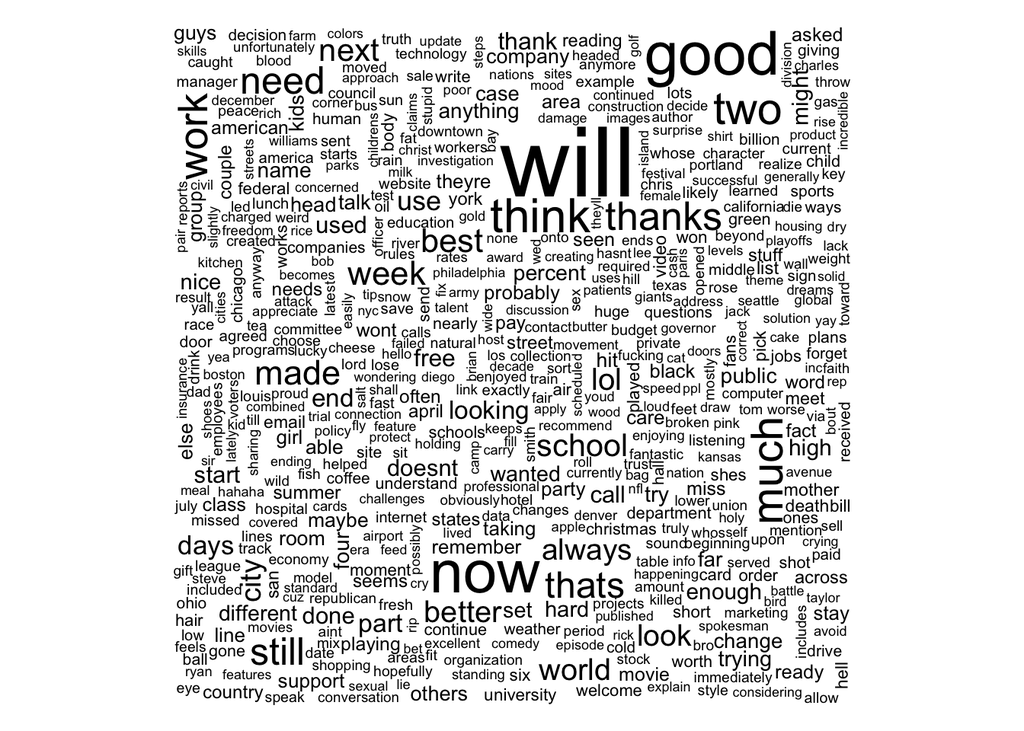

## Term Document Matrix

If we stem the corpus and take a look at TDM, we can see that there is less overlap of words accross the documents than you would think and you can see the top 10 words

```
## <<TermDocumentMatrix (terms: 41435, documents: 3)>>
## Non-/sparse entries: 61626/62679
## Sparsity           : 50%
## Maximal term length: 88
## Weighting          : term frequency (tf)
```

```
## will  one said just like  get time  can  day year
## 3191 3074 3074 2993 2978 2932 2562 2444 2251 2153
```

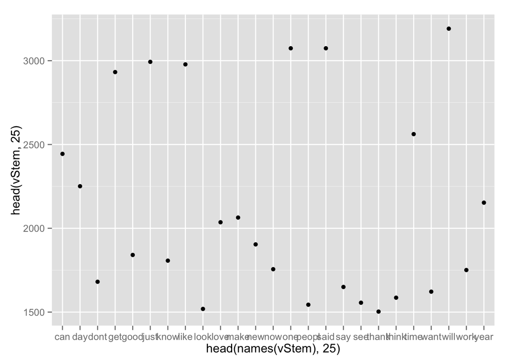

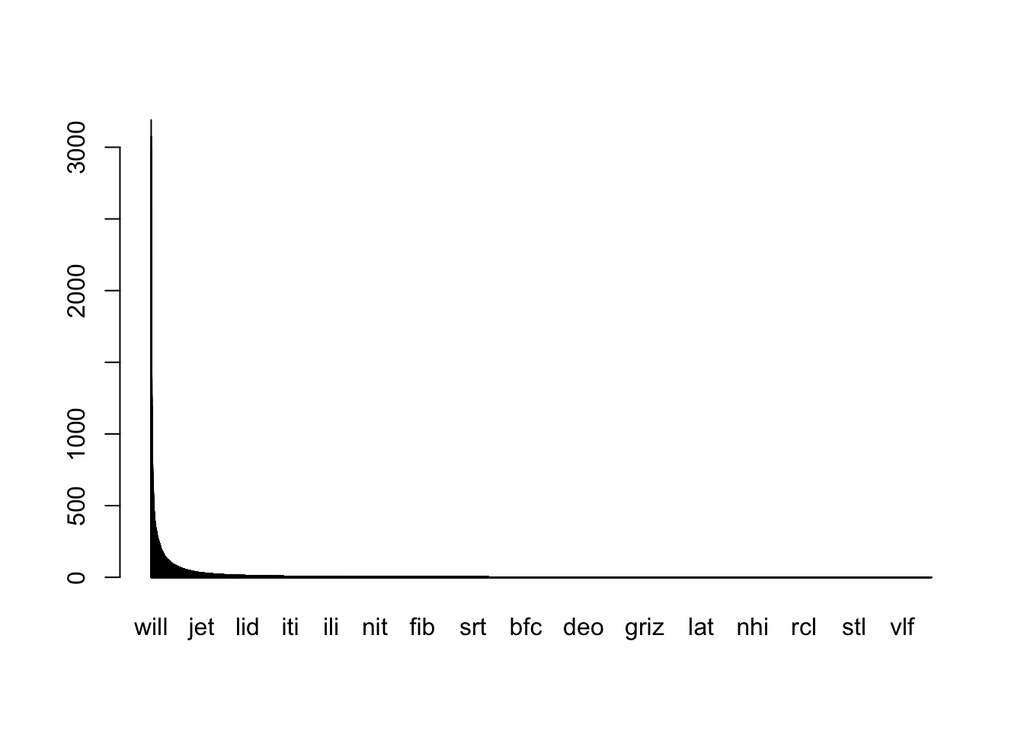

## N-gram Tokenization

The tables below show the top 2 and 3-gram frequncies by document

Twitter:

```
## bitwitterGrams
##       cant wait       right now      last night looking forward
##             166             164             112              93
##        im going       dont know  happy birthday        just got
##              84              82              79              76
##    good morning       feel like      looks like        let know
##              73              65              61              58
##       next week         can get     mothers day       good luck
##              57              55              53              52
##     sounds like   thanks follow     follow back         im just
##              51              50              49              49
```

```
## twitterGrams
##      happy mothers day          cant wait see      alone alone alone
##                     30                     29                     21
##            let us know         im pretty sure         dont even know
##                     19                     11                     10
##          cant wait get           job need job looking forward seeing
##                      9                      9                      9
##          need job need          cinco de mayo          just got back
##                      9                      8                      8
##         cant wait till            come see us        happy new years
##                      7                      7                      7
##   happy valentines day         add boston add      boston add boston
##                      7                      6                      6
##         cant wait hear         cant wait read
##                      6                      6
```

Blogs:

```
## biblogsGrams
##   dont know   right now   feel like    im going   last year   years ago
##          65          55          50          50          48          48
##  first time     im sure even though    new york   make sure   dont want
##          45          45          42          42          39          37
##  last night     one day  dont think   last week     can see     can get
##          37          36          35          35          33          32
## high school   every day
##          32          29
```

```
## blogsGrams
##      cant make spouse  nolita italy fashion         new york city
##                    13                    13                     9
##   ferrari f challenge      couple weeks ago        dont get wrong
##                     8                     7                     7
##    f challenge arcade    im looking forward      thought id share
##                     6                     6                     6
##      every single day           im going go        im pretty sure
##                     5                     5                     5
##  italy pashmina italy       jeep sioux city        just make sure
##                     5                     5                     5
##     lord jesus christ quoth raven nevermore       sioux city iowa
##                     5                     5                     5
##      almost years ago challenge arcade game
##                     4                     4
```

News:

```
## binewsGrams
##      last year       new york       st louis      last week      years ago
##            143            130             80             73             71
##    high school     new jersey      two years     first time    los angeles
##             68             66             60             53             50
##     last month    health care      right now  san francisco    three years
##             46             41             40             39             38
## vice president      dont know    police said  united states    even though
##             38             37             37             37             36
```

```
## newsGrams
##                 new york city        president barack obama
##                            18                            17
##                 two years ago            gov chris christie
##                            15                            11
##                  world war ii               st louis county
##                            11                            10
##      executive vice president         senior vice president
##                             8                             8
##       chief executive officer                five years ago
##                             7                             7
##                 george w bush      national weather service
##                             7                             7
##               three years ago       chief operating officer
##                             7                             6
##            high school sports                 st louis area
##                             6                             6
##         afc championship game          dow jones industrial
##                             5                             5
## former massachusetts governor        gross domestic product
##                             5                             5
```

## Conclusion

The data overall shows that purging posseive semi-colons would be detrimnal to prediction, while also perhaps showing that up to 3 N-grams would be appropriate. We will refine this appraoch as we move to the model phase.